# ATAC-seq HOMEWORK

Group 3

February 12, 2024

## Human Myeloid Differentiation based on Monocytes

Dataset RNA-seq: GSE79044 Dataset ATAC-seq: GSE79019 Purpose: Identify differences in chromatin regions profiles in monocytes at 3 time points of differentiation: 3h, 6h, 12h. Investigate if the RNA-seq expression data follows the same trend corresponding to differential peaks.

Paper: Ramirez RN, El-Ali NC, Mager MA, Wyman D, Conesa A, Mortazavi A. Dynamic Gene Regulatory Networks of Human Myeloid Differentiation. Cell Syst. 2017 Apr 26;4(4):416-429.e3. doi: 10.1016/j.cels.2017.03.005. Epub 2017 Mar 29. PMID: 28365152; PMCID: PMC5490374

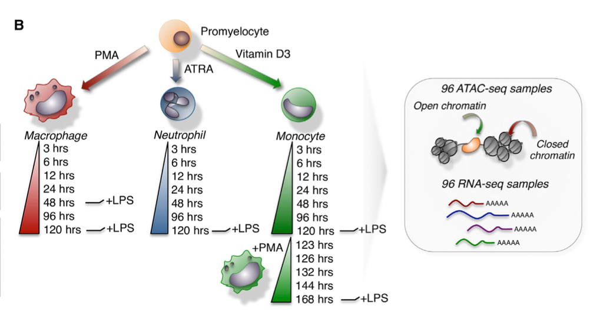

### Load the data

```r
####################
# FROM GEO samples #
####################
# set up
rm(list = ls())
library(rtracklayer) #reading genomic info
library(GenomicRanges) #intervals of regions

setwd("/Users/kurowsaa/OneDrive/Documents/KAUST/Bioinfo_pipelines_course/WEEK_3/")

# control panel
raw_data_folder <- 'GSE79019_RAW'
min_overlap <- 0.3 #min overlap - 3bp for both peaks for replicates of each timepoint, we can be strict with the threshold here, as we expect the biological replicates from the same time point to have aligned signal
chromosomes <- paste0('chr', c(1:22, 'X', 'Y')) #keep only known and defined chromosomes

# bed files
bed_files <- file.path(raw_data_folder,
                       dir(raw_data_folder, pattern = '*.bed'))
```

### Find consensus peaks for each time point independently, by merging the replicates of each time point

It is important to find consensus peaks separately for each timepoint of the differentiation, to provide unique input for differential expression analysis.

```r
# Select bed files of replicates for each time point
mono_3h <- bed_files[1:3]
mono_6h <- bed_files[4:6]
mono_12h <- bed_files[7:9]

bed_list <- list(mono_3h, mono_6h, mono_12h)

consensus <- list()
for(i in 1:length(bed_list)){
  #import bed files
  bed_1 <- import(bed_list[[i]][1])
  bed_2 <- import(bed_list[[i]][2])
  bed_3 <- import(bed_list[[i]][3])

  #Select only chosen chromosomes
  bed_1 <- bed_1[seqnames(bed_1) %in% chromosomes]
  seqlevels(bed_1) <- chromosomes
  bed_2 <- bed_2[seqnames(bed_2) %in% chromosomes]
  seqlevels(bed_2) <- chromosomes
  bed_2 <- bed_2[seqnames(bed_2) %in% chromosomes]
  seqlevels(bed_2) <- chromosomes

  #Ready files for consensus peaks
  files <- list(bed_1, bed_2, bed_3)

  for(j in 1:(length(files)-1)){
    # finding overlap between reference_bed and another bed file
    reference_bed <- files[[1]]
    which_file <- j+1
    new_bed <- files[[which_file]]
    hits <- findOverlaps(reference_bed, new_bed)
    # quantify the overlap
    overlaps <- pintersect(reference_bed[queryHits(hits)], new_bed[subjectHits(hits)])
    # overlap fraction with respect to the original peaks
    percent_overlap_on_1 <- width(overlaps) / width(reference_bed[queryHits(hits)])
    percent_overlap_on_2 <- width(overlaps) / width(new_bed[subjectHits(hits)])
    hits <- hits[percent_overlap_on_1 > min_overlap &
                 percent_overlap_on_2 > min_overlap]
    # subsetting the bed files
    reference_bed <- reference_bed[queryHits(hits)]
    new_bed <- new_bed[subjectHits(hits)]
    # "reducing" the peaks
    start_1 <- start(reference_bed)
    end_1 <- end(reference_bed)
    start_2 <- start(new_bed)
    end_2 <- end(new_bed)
    reduced_start <- pmin(start_1, start_2)
    reduced_end <- pmax(end_1, end_2)
    new_reference_bed <- reference_bed
    start(new_reference_bed) <- reduced_start
    end(new_reference_bed) <- reduced_end
    files[[1]] <- new_reference_bed
    print(length(files[[1]]))
  }

  # Save consensus peaks of each time point by removing duplicated regions
  consensus[[i]] <- reduce(files[[1]])
}
```

```
## [1] 7482
## [1] 7390
## [1] 10250
## [1] 9962
## [1] 8659
## [1] 8587
```

```r
names(consensus) <- c("consens_3h", "consens_6h", "consens_12h")
```

### Merge consensus peaks from all of the time points (unique + duplicated)

```r
# Inpsect
summary(consensus)
```

```
##             Length Class   Mode
## consens_3h  7200   GRanges S4
## consens_6h  9660   GRanges S4
## consens_12h 8469   GRanges S4
```

```r
#            Length Class   Mode
#consens_3h  7200   GRanges S4
#consens_6h  9660   GRanges S4
#consens_12h 8469   GRanges S4

# On average we get ~8.4k consensus peaks for each time point from the replicates,

# peak union!
union_reference_bed <- c(consensus[[1]], consensus[[2]], consensus[[3]]) #25329 peaks from 3 timepoints
length(union_reference_bed)
```

```
## [1] 25329
```

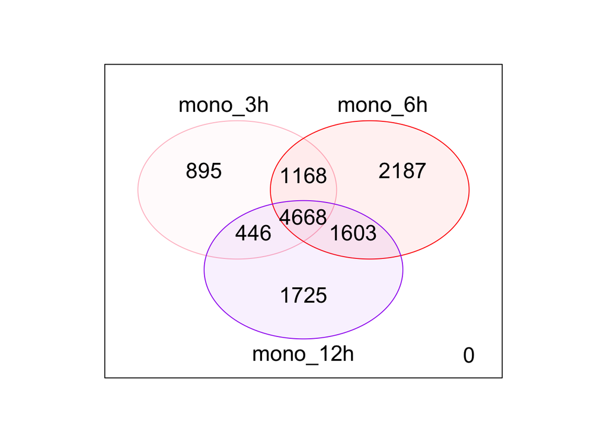

```r
# FINAL CONSENSUS: Select all peaks (common and unique) and merge peaks closer than 30bp

library(GenomicRanges)
library(ChIPpeakAnno)
library(limma)

peak_overlap <- findOverlapsOfPeaks(consensus[[1]], consensus[[2]], consensus[[3]], maxgap = 31, connectedPeaks = "merge")

# Plot venn diagram of overlaps
vennDiagram(peak_overlap$venn_cnt, names = c("mono_3h","mono_6h", "mono_12h"), circle.col = c("pink","red","purple"))
```

```r
# We have 4668 common peaks shared between all 3 time points
# 1168 peaks shared between 3h and 6h
# 1603 peaks shared between 6h and 12h
# 446 peaks shared between 3h adn 12h
# 895 unique peaks for 3h
# 2187 unique peaks for 6h
# 1725 unique peaks for 12h

peak_overlap <- peak_overlap$peaklist
length(peak_overlap)
```

```
## [1] 7
```

```r
peak_overlap <- c(peak_overlap[[1]], peak_overlap[[2]], peak_overlap[[3]], peak_overlap[[4]],
                peak_overlap[[5]], peak_overlap[[6]], peak_overlap[[7]])

peak_overlap <- sort(peak_overlap)
summary(peak_overlap)
```

```
## [1] "GRanges object with 12691 ranges and 1 metadata column"
```

```r
#"GRanges object with 12691 ranges and 1 metadata column"
```

### Clean peaks

```r
# loading black listed regions - repetitive motives
# https://www.encodeproject.org/annotations/ENCSR636HFF/
black_listed_bed <- import('ENCFF356LFX.bed')

# any hit?
hits <- findOverlaps(peak_overlap, black_listed_bed)
hits #143
```

```
## Hits object with 143 hits and 0 metadata columns:
##         queryHits subjectHits
##         <integer>   <integer>
##     [1]       314          13
##     [2]       948          49
##     [3]       949          51
##     [4]       950          51
##     [5]       951          52
##     ...       ...         ...
##   [139]     12686         899
##   [140]     12687         900
##   [141]     12688         906
##   [142]     12689         906
##   [143]     12691         910
##   -------
##   queryLength: 12691 / subjectLength: 910
```

```r
# what about the length of the overlap?
overlaps <- pintersect(peak_overlap[queryHits(hits)],
                       black_listed_bed[subjectHits(hits)])
summary(width(overlaps)/width(peak_overlap[queryHits(hits)]))
```

```
##    Min. 1st Qu.  Median    Mean 3rd Qu.    Max.
## 0.01397 0.88768 1.00000 0.91290 1.00000 1.00000
```

```r
# eliminating the blacklisted regions
union_reference_bed <- peak_overlap[-queryHits(hits)]

# Name peaks
head(union_reference_bed)
```

```
## GRanges object with 6 ranges and 1 metadata column:
##       seqnames          ranges strand |
##          <Rle>       <IRanges>  <Rle> |
##   [1]     chr1   778407-779001      * |
##   [2]     chr1   827238-828083      * |
##   [3]     chr1 1115967-1116567      * |
##   [4]     chr1 1231515-1232381      * |
##   [5]     chr1 1307912-1308628      * |
##   [6]     chr1 1324477-1325281      * |
##                                                            peakNames
##                                                      <CharacterList>
##   [1] consensus..2..__0001,consensus..3..__0001,consensus..1..__0001
##   [2] consensus..3..__0002,consensus..2..__0002,consensus..1..__0002
##   [3] consensus..1..__0003,consensus..2..__0003,consensus..3..__0003
##   [4] consensus..1..__0004,consensus..2..__0004,consensus..3..__0004
##   [5]                      consensus..2..__0005,consensus..3..__0005
##   [6]                                           consensus..2..__0006
##   -------
##   seqinfo: 24 sequences from an unspecified genome; no seqlengths
```

```r
consensus <- as.data.frame(union_reference_bed)
consensus <- consensus[,1:3]
consensus[,4] <- paste0("ConsensusPeak_", 1:nrow(consensus))
consensus[,5] <- 0
consensus[,6] <- "."

# writing the reference
export.bed(consensus, con = 'reference.bed')

# We get at the end 12551 merged peaks between 3 time points
```

### Generate counts matrix

```r
# control panel
raw_data_folder <- 'GSE79019_RAW'
read_length <- 36
chromosomes <- paste0('chr', c(1:22, 'X', 'Y'))
reference_file <- 'reference.bed'

# bw files
bw_files <- file.path(raw_data_folder, dir(raw_data_folder, pattern = '*.bw'))

# loading reference bed
peaks <- import(reference_file)

# count matrix
count_matrix <- matrix(0, length(peaks), length(bw_files))
rownames(count_matrix) <- paste0(seqnames(peaks), '_', start(peaks), '_', end(peaks))
colnames(count_matrix) <- letters[1:length(bw_files)]

# looping over files
for(i in 1:length(bw_files)){

  # current files
  print(paste0('sample ', i, ' out of ', length(bw_files)))
  bw_file <- bw_files[i]

  # sample name
  sample_name <- gsub(raw_data_folder, '', bw_file, fixed = TRUE)
  sample_name <- gsub('.bw', '', sample_name, fixed = TRUE)
  sample_name <- gsub('/', '', sample_name, fixed = TRUE)
  sample_name <- strsplit(sample_name, '_')[[1]][2]
  # if(grepl('HL60', sample_name)){
  #   sample_name <- paste0('T0h-', sample_name)
  # }else{
  #   sample_name <- paste0('T', sample_name)
  # }

  # loadind and downsizing the bigwigfile
  bw_file_list <- BigWigFileList(bw_file)
  coverage <- import(bw_file_list[[1]], as = 'RleList')
  coverage <- coverage[names(coverage) %in% chromosomes]

  # split the peaks across chromosomes
  peaks_list <- split(peaks, seqnames(peaks))

  # coverage per peak
  coverage <- coverage[names(peaks_list)]
  peaks_coverage <- Views(coverage, ranges(peaks_list))

  # count values
  counts <- sapply(peaks_coverage, sum)

  # ensuring to have the right peak information
  chrs <- rep(names(peaks_coverage), sapply(peaks_coverage, length))
  starts <- sapply(peaks_coverage, start)
  ends <- sapply(peaks_coverage, end)

  # converting to vector
  counts <- unlist(counts)
  names(counts) <- paste0(chrs, '_', unlist(starts), '_', unlist(ends))

  # rounding up
  counts <- round(counts / read_length)

  # count as data frame
  count_matrix[names(counts), i] <- counts
  colnames(count_matrix)[i] <- sample_name

}
```

```
## [1] "sample 1 out of 9"
## [1] "sample 2 out of 9"
## [1] "sample 3 out of 9"
## [1] "sample 4 out of 9"
## [1] "sample 5 out of 9"
## [1] "sample 6 out of 9"
## [1] "sample 7 out of 9"
## [1] "sample 8 out of 9"
## [1] "sample 9 out of 9"
```

```r
# writing
count_matrix <- as.data.frame(count_matrix)
count_matrix <- cbind(peak = rownames(count_matrix), count_matrix) #12551  x  10
head(count_matrix)
```

```
##                                      peak 3h-Mon-Rep1 3h-Mon-Rep2 3h-Mon-Rep3
## chr1_778407_779001     chr1_778407_779001          19          40          37
## chr1_827238_828083     chr1_827238_828083          19          60          39
## chr1_1115967_1116567 chr1_1115967_1116567          19          68          39
## chr1_1231515_1232381 chr1_1231515_1232381          12          46          32
## chr1_1307912_1308628 chr1_1307912_1308628           9          58          58
## chr1_1324477_1325281 chr1_1324477_1325281          12          30          19
##                      6h-Mon-Rep1 6h-Mon-Rep2 6h-Mon-Rep3 12h-Mon-Rep1
## chr1_778407_779001            29          49          37           26
## chr1_827238_828083            20          36          38           26
## chr1_1115967_1116567          21          27          44           27
## chr1_1231515_1232381          19          41          37           23
## chr1_1307912_1308628          27          39          49           23
## chr1_1324477_1325281          13          13          13           12
##                      12h-Mon-Rep2 12h-Mon-Rep3
## chr1_778407_779001              8           53
## chr1_827238_828083              9           59
## chr1_1115967_1116567           12           47
## chr1_1231515_1232381            9           41
## chr1_1307912_1308628            9           48
## chr1_1324477_1325281            4           19
```

```r
write.csv(count_matrix, row.names = FALSE,
          file = 'count_matrix.csv')
```